# Weather and Storm data analysis

Karim.bnm

7 février 2016

# Summary

This file covers an exploration of the NOAA storm database which can be found [here](https://d396qusza40orc.cloudfront.net/repdata%2Fdata%2FStormData.csv.bz2). Documentation about the data is [here](https://d396qusza40orc.cloudfront.net/repdata%2Fpeer2_doc%2Fpd01016005curr.pdf).

This analysis covers two questions :

- Across the United States, which types of events (as indicated in the EVTYPE variable) are most harmful with respect to population health?
- Across the United States, which types of events have the greatest economic consequences?

The analysis shows that TORNADOES are, in general, the most harmful events with regards to human health, and the disasters having the greatest economic consequence.

## Environment

```r
library(ggplot2)
library(dplyr)
```

## Data processing

```r
url <- "https://d396qusza40orc.cloudfront.net/repdata%2Fdata%2FStormData.csv.bz2" #url to compressed datafile
url2 <- "https://d396qusza40orc.cloudfront.net/repdata%2Fpeer2_doc%2Fpd01016005curr.pdf" #url to the data documentation
download.file(url, "stormdata.csv.bz2")
download.file(url2, "stormdatadoc.pdf")
dt <- read.csv("stormdata.csv.bz2", stringsAsFactors = TRUE, na.strings = c("", "NA"))
```

The file contains 902297 observations along 37 variables.

First, I proceeded with a few transformations : - for the first question, I aggregated the number of casualties along with the type of events. Specifically, the number of victims due to storm events is gathered in the FATALITIES and INJURIES variables. I created a new variable called CASUALTIES which is the sum of FATALITIES and INJURIES grouped by EVENT TYPES. Then, I plotted the 1% type of events with caused the most casualties. - for the second question, I recoded the factor levels of PROPDMGEXP and CROPDMGEXP before calculating the total costs per type of events (into a variable called ECOCONS). Then, I plotted the 25% type of events with the greatest economic consequences.

```r
#QUESTION 1
# create a dataframe with EVENT TYPES and CASUALTIES (2 variables)
dt2 <- dt %>% group_by(EVTYPE) %>% select(EVTYPE, FATALITIES, INJURIES) %>% mutate(CASUALTIES = FATALITIES + INJURIES, FATALITIES = FATALITIES, INJURIES = INJURIES)

# create a dataframe with the sum of casualties for each EVENT
dt2.1 <- aggregate(CASUALTIES~EVTYPE, data = dt2, FUN=sum)

# create a dataframe with the 1% most harmful events
dt2.2 <- group_by(subset(dt2.1, CASUALTIES>=quantile(dt2.1$CASUALTIES, probs=0.99)), EVTYPE)

#QUESTION 2
# create a dataframe with damage costs (4 variables) and event types

dt3 <- dt %>% group_by(EVTYPE) %>% select(EVTYPE, PROPDMG, PROPDMGEXP, CROPDMG, CROPDMGEXP)

# recoding PROPDMGEXP and CROPDMGEXP before calculating the total cost per event type

dt3$PROPDMGEXPNUM <- factor(toupper(dt3$PROPDMGEXP), levels = c("B", "M", "K", "H", ""), labels = c(10^9, 10^6, 10^3, 10^2, 0))
dt3$CROPDMGEXPNUM <- factor(toupper(dt3$CROPDMGEXP), levels = c("B", "M", "K", "" ), labels = c(10^9, 10^6, 10^3, 0))

dt3 <- dt3%>% mutate (PROPDMGEXPCALC = PROPDMG*as.numeric(as.character(PROPDMGEXPNUM)), CROPDMGEXPCALC = CROPDMG*as.numeric(as.character(CROPDMGEXPNUM))) %>% group_by(EVTYPE) %>% summarize(ECOCONS = sum(PROPDMGEXPCALC+CROPDMGEXPCALC))

dt3 <- as.data.frame(dt3)

#compute the 25% event types with the greatest economic consequence
dt3.1 <- group_by(subset(dt3, ECOCONS>=quantile(dt3$ECOCONS, probs=0.75, na.rm=T)), EVTYPE)
```

# Results

## Most harmful type of events with respect to health population

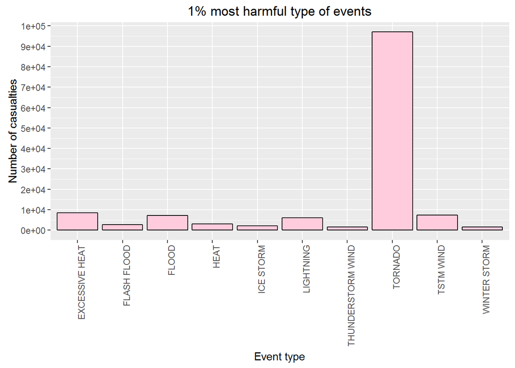

```r
# Identification of the most harmful event
mostharmful <- as.character(dt2.1[which(dt2.1$CASUALTIES==max(dt2.1$CASUALTIES)),1])

# Percentage of casualties due to the most harmful event
percentage <- round(dt2.1$CASUALTIES[dt2.1$EVTYPE==mostharmful]/sum(dt2.1$CASUALTIES)*100,2)

# Plot the 1% most harmful events
ggplot(dt2.2, aes(x=EVTYPE, y=CASUALTIES)) +
    geom_bar(stat="identity", colour="black", fill="#FFCCDD") +
    theme(axis.text.x = element_text(angle = 90, hjust = 1)) +
    xlab("Event type") +
    ylab("Number of casualties") +
    scale_y_continuous(breaks=seq(0,100000, 10000)) +
    ggtitle("1% most harmful type of events")
```

The most harmful type of events with respect to health population is TORNADO.

It represents 62.3% of the total casualties.

## Type of events which have the greatest economic consequence

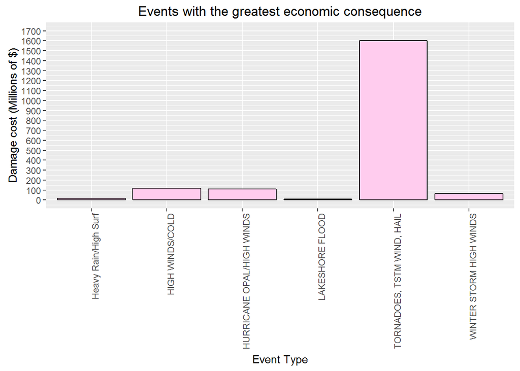

```r
# Identification of the type of events which have the greatest economic consequences

mostcostly <- as.character(dt3[which(dt3$ECOCONS==max(dt3$ECOCONS, na.rm = TRUE)), 1])

# Percentage of damage cost due to this type of event

percentage2 <- round(dt3$ECOCONS[dt3$EVTYPE==mostcostly]/sum(dt3$ECOCONS, na.rm = T)*100, 2)

# Plot the type of events which amounts for 25% of the total damage cost.

ggplot(dt3.1, aes(x=EVTYPE, y=ECOCONS/10^6)) +
    geom_bar(stat="identity", colour="black", fill="#FFCCEE") +
    theme(axis.text.x = element_text(angle = 90, hjust = 1)) +
    coord_cartesian(ylim=c(0, 1700)) +
    xlab("Event Type") +
    ylab("Damage cost (Millions of $)") +
    scale_y_continuous(breaks=seq(0,1700, 100)) +
    ggtitle("Events with the greatest economic consequence")
```

This histogram summarizes the type of events with the greatest economic consequence.

The type of events which have the greatest economic consequence is TORNADOES, TSTM WIND, HAIL.

It represents 82.68 % of the total costs caused by disaster events.